The imported CarSales dataset has 9379 observations and 32 variables. The geographical level used in this analysis is state and will be used to determine the most used car or new car in this platform.

```r
library(readxl)
cars<-read_excel("CarSales.xlsx")
#check the structure
#str(cars)
head(cars)
```

```
## # A tibble: 6 × 32
##    Year Make   Model       Used/…¹ Price Consu…² Consu…³ Selle…⁴ Selle…⁵ Selle…⁶
##   <dbl> <chr>  <chr>       <chr>   <chr>   <dbl>   <dbl> <chr>   <chr>     <dbl>
## 1  2019 Toyota Sienna SE   Used    39998     4.6      45 Dealer  CarMax…     3.3
## 2  2018 Ford   F-150 Lari… Used    49985     4.8     817 Dealer  Giant …     4.8
## 3  2017 RAM    1500 Laram… Used    41860     4.7     495 Dealer  Gill A…     4.6
## 4  2021 Honda  Accord Spo… Used    28500     5        36 Dealer  AutoSa…     4.6
## 5  2020 Lexus  RX 350      Used    49000     4.8      76 Dealer  Lexus …     4.8
## 6  2012 Toyota 4Runner SR5 Used    23541     4.7      34 Dealer  AutoNa…     4.4
## # … with 22 more variables: SellerReviews <dbl>, StreetName <chr>, State <chr>,
## #   Zipcode <chr>, DealType <chr>, ComfortRating <dbl>,
## #   InteriorDesignRating <dbl>, PerformanceRating <dbl>,
## #   ValueForMoneyRating <dbl>, ExteriorStylingRating <dbl>,
## #   ReliabilityRating <dbl>, ExteriorColor <chr>, InteriorColor <chr>,
## #   Drivetrain <chr>, MinMPG <dbl>, MaxMPG <dbl>, FuelType <chr>,
## #   Transmission <chr>, Engine <chr>, VIN <chr>, `Stock#` <chr>, …
```

Before beginning our analysis, we will need to convert variable Used/New to a factor in the code chunk below. We then rename the certified brands into New.

```r
#convert into a factor variable
cars$`Used/New`<-as.factor(cars$`Used/New`)
#rename the levels
cars$`used/new` <-ifelse(cars$`Used/New`=="Used","used","new")
```

```r
table(cars$`used/new`)
```

```
##
##  new used
## 1479 7900
```

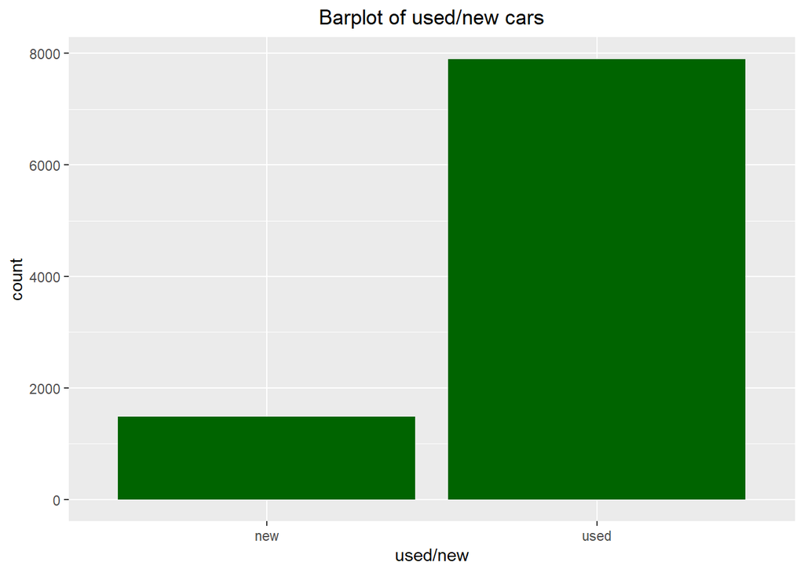

```r
library(ggplot2)
library(ggeasy)
ggplot(cars,aes(`used/new`))+
  geom_bar(fill="darkgreen")+
  ggtitle("Barplot of used/new cars")+
  ggeasy::easy_center_title()
```

The results show that there are more used cars(7900) as compared to the new ones(1479).Also from the barlot above, the bar representing used cars is longer than for the new cars.

```r
library(tidyverse)
##state with the most used cars
df1<-cars %>%
  select(`used/new`,State) %>%
  filter(`used/new`=="used") %>%
  group_by(State,`used/new`) %>%
  count() %>%
  arrange(-n) %>%
  ungroup()
df1
```

```
## # A tibble: 59 × 3
##    State `used/new`     n
##    <chr> <chr>      <int>
##  1 TX    used        1069
##  2 FL    used         731
##  3 CA    used         554
##  4 IL    used         504
##  5 NY    used         357
##  6 GA    used         354
##  7 NJ    used         290
##  8 VA    used         290
##  9 MD    used         289
## 10 OH    used         288
## # … with 49 more rows
```

The state with the highest count of used cars is TX with a count of 1069 used cars.

```r
##state with the most new cars
df2<-cars %>%
  select(`used/new`,State) %>%
  filter(`used/new`=="new") %>%
  group_by(State,`used/new`) %>%
  count() %>%
  arrange(-n) %>%
  ungroup()
df2
```

```
## # A tibble: 48 × 3
##    State `used/new`     n
##    <chr> <chr>      <int>
##  1 FL    new          157
##  2 TX    new          156
##  3 CA    new          114
##  4 IL    new           89
##  5 MI    new           85
##  6 NY    new           83
##  7 MA    new           68
##  8 AZ    new           61
##  9 PA    new           55
## 10 VA    new           50
## # … with 38 more rows
```

The state with the most new cars is FL with a count of 157 cars.

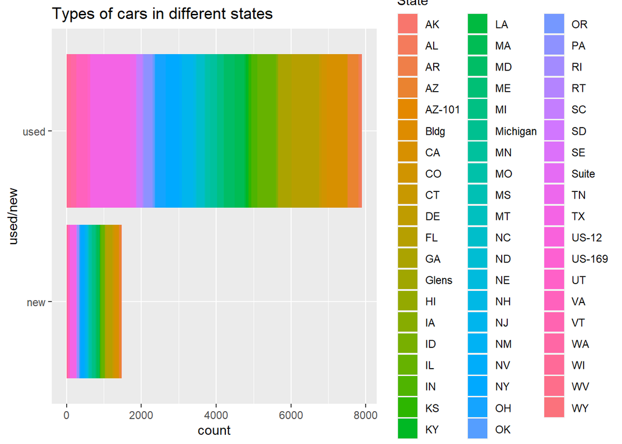

```r
##plotting according to state
cars %>%
  ggplot(aes(`used/new`,fill=State))+
  geom_bar()+
  coord_flip()+
  ggtitle("Types of cars in different states")
```

In the plot above, there are too many states hence visualization is not very clear but one can use the different colours to identify the state associated with the type of car whether used or new